# 06: ggplot

Hannah Houts & Bryshal Moore

In yesterday’s tutorial, we tested out generating a PCoA plot using ggplot (and vegan). Today, we’ll delve into ggplot in more detail, exploring its various features and functionalities.

ggplot2 (commonly just referred to as just ggplot) is a R package used to make high quality plots for your data. *ggplot2 is part of the tidyverse suite!* It offers consistent syntax and allows for detailed customization of almost every element of your plots. Visualization options range from bargraphs, boxplots, scatterplot, pie charts, histograms and more.

to get started, lets load tidyverse (we’re going to use a few dplyr functions in addition to ggplot, so loading tidyverse is a quick solution)

```r
library(tidyverse)
```

Lets check out a new science (fiction) dataset, and check out it’s columns:

```r
powers <- read_csv("https://raw.githubusercontent.com/mblstamps/stamps2023/main/day1/intro_R/super_data/super_hero_powers.csv")
powers
```

```
## # A tibble: 667 × 168
##    hero_names    Agility `Accelerated Healing` `Lantern Power Ring`
##    <chr>         <lgl>   <lgl>                 <lgl>
##  1 3-D Man       TRUE    FALSE                 FALSE
##  2 A-Bomb        FALSE   TRUE                  FALSE
##  3 Abe Sapien    TRUE    TRUE                  FALSE
##  4 Abin Sur      FALSE   FALSE                 TRUE
##  5 Abomination   FALSE   TRUE                  FALSE
##  6 Abraxas       FALSE   FALSE                 FALSE
##  7 Absorbing Man FALSE   FALSE                 FALSE
##  8 Adam Monroe   FALSE   TRUE                  FALSE
##  9 Adam Strange  FALSE   FALSE                 FALSE
## 10 Agent Bob     FALSE   FALSE                 FALSE
## # ℹ 657 more rows
## # ℹ 164 more variables: `Dimensional Awareness` <lgl>, `Cold Resistance` <lgl>,
## #   Durability <lgl>, Stealth <lgl>, `Energy Absorption` <lgl>, Flight <lgl>,
## #   `Danger Sense` <lgl>, `Underwater breathing` <lgl>, Marksmanship <lgl>,
## #   `Weapons Master` <lgl>, `Power Augmentation` <lgl>,
## #   `Animal Attributes` <lgl>, Longevity <lgl>, Intelligence <lgl>,
## #   `Super Strength` <lgl>, Cryokinesis <lgl>, Telepathy <lgl>, …
```

see how a few of the names have spaces in them, and some of them start with uppercase letters? the package `janitor` has a function that “cleans up” column names according to their standards (read more here:https://rpubs.com/jenrichmond/clean_names)

```r
if (!requireNamespace("janitor", quietly = TRUE)) {
     install.packages("janitor")
}
library(janitor)
powers <- clean_names(powers)
powers
```

```
## # A tibble: 667 × 168
##    hero_names    agility accelerated_healing lantern_power_ring
##    <chr>         <lgl>   <lgl>               <lgl>
##  1 3-D Man       TRUE    FALSE               FALSE
##  2 A-Bomb        FALSE   TRUE                FALSE
##  3 Abe Sapien    TRUE    TRUE                FALSE
##  4 Abin Sur      FALSE   FALSE               TRUE
##  5 Abomination   FALSE   TRUE                FALSE
##  6 Abraxas       FALSE   FALSE               FALSE
##  7 Absorbing Man FALSE   FALSE               FALSE
##  8 Adam Monroe   FALSE   TRUE                FALSE
##  9 Adam Strange  FALSE   FALSE               FALSE
## 10 Agent Bob     FALSE   FALSE               FALSE
## # ℹ 657 more rows
## # ℹ 164 more variables: dimensional_awareness <lgl>, cold_resistance <lgl>,
## #   durability <lgl>, stealth <lgl>, energy_absorption <lgl>, flight <lgl>,
## #   danger_sense <lgl>, underwater_breathing <lgl>, marksmanship <lgl>,
## #   weapons_master <lgl>, power_augmentation <lgl>, animal_attributes <lgl>,
## #   longevity <lgl>, intelligence <lgl>, super_strength <lgl>,
## #   cryokinesis <lgl>, telepathy <lgl>, energy_armor <lgl>, …
```

### Practice 1.

Try out janitor on the supers_hero_powers data

```r
superhero_info <- read_csv("https://raw.githubusercontent.com/mblstamps/stamps2023/main/day1/intro_R/super_data/heroes_information.csv")
# add code to clean names below!

superhero_info <- clean_names(superhero_info)
```

lets take that superpowers dataframe and make a plot!

```r
tabyl(dat = superhero_info$skin_color)
```

```
##  superhero_info$skin_color   n     percent
##                          - 662 0.901907357
##                      black   1 0.001362398
##                       blue   9 0.012261580
##                 blue-white   1 0.001362398
##                       gold   3 0.004087193
##                       gray   1 0.001362398
##                      green  21 0.028610354
##                       grey   5 0.006811989
##                     orange   1 0.001362398
##             orange / white   1 0.001362398
##                       pink   2 0.002724796
##                     purple   3 0.004087193
##                        red   9 0.012261580
##                red / black   1 0.001362398
##                     silver   5 0.006811989
##                      white   7 0.009536785
##                     yellow   2 0.002724796
```

```r
superhero_info %>%
  arrange(desc(height))
```

```
## # A tibble: 734 × 10
##    name  gender eye_color race  hair_color height publisher skin_color alignment
##    <chr> <chr>  <chr>     <chr> <chr>       <dbl> <chr>     <chr>      <chr>
##  1 Fin … Male   red       Kaka… No Hair      975  Marvel C… green      good
##  2 Gala… Male   black     Cosm… Black        876  Marvel C… -          neutral
##  3 Groot Male   yellow    Flor… -            701  Marvel C… -          good
##  4 MODOK Male   white     Cybo… Brownn       366  Marvel C… -          bad
##  5 Wolf… Female green     -     Auburn       366  Marvel C… -          good
##  6 Onsl… Male   red       Muta… No Hair      305  Marvel C… -          bad
##  7 Sasq… Male   red       -     Orange       305  Marvel C… -          good
##  8 Ymir  Male   white     Fros… No Hair      305. Marvel C… white      good
##  9 Rey   Female hazel     Human Brown        297  George L… -          good
## 10 Jugg… Male   blue      Human Red          287  Marvel C… -          neutral
## # ℹ 724 more rows
## # ℹ 1 more variable: weight <dbl>
```

say we want to make a bar chart to visualize the relative heights of superheros. This is about the simplest version we can make using ggplot.

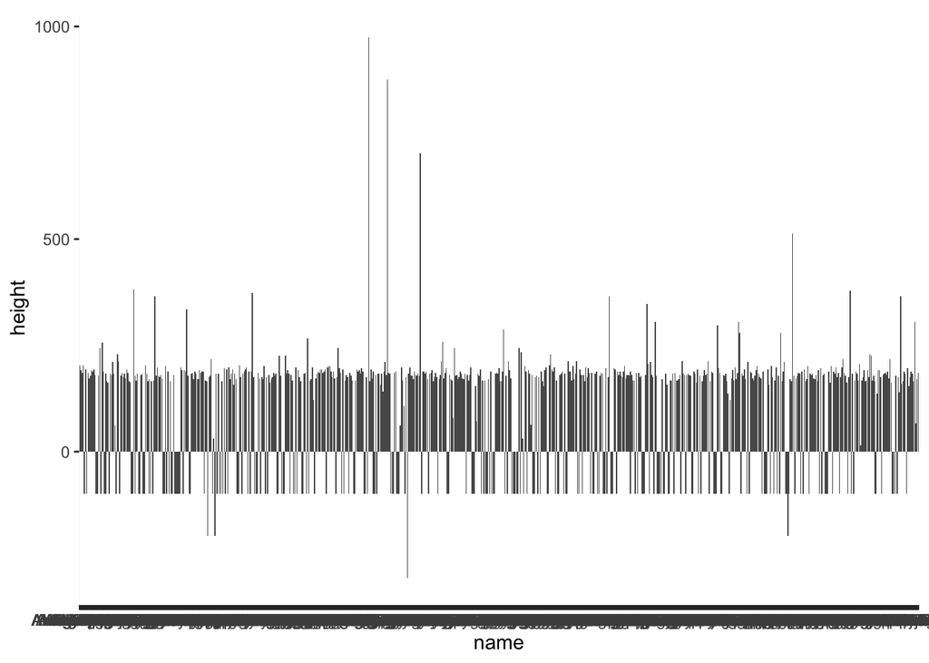

```r
superhero_info %>%
  ggplot(aes(x = name, y = height)) +
  geom_col()
```

Although the above code is equivalent to:

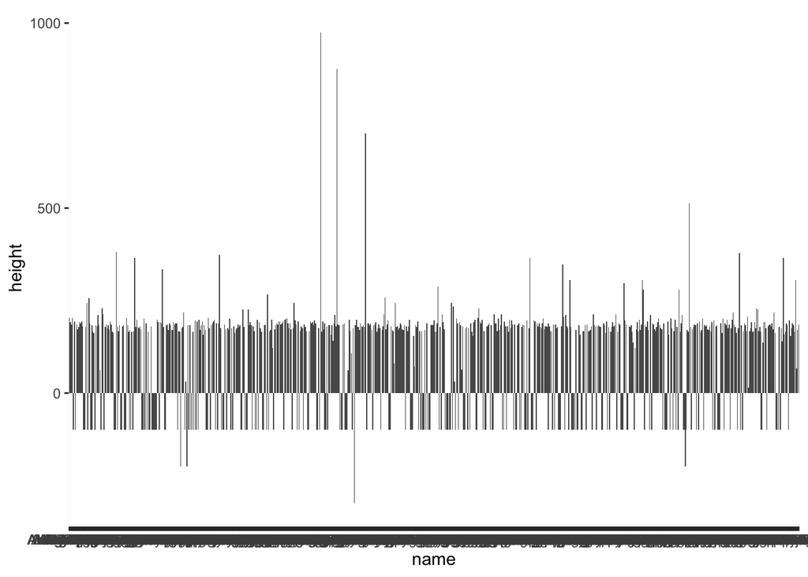

```r
  ggplot(superhero_info, aes(x = name, y = height)) +
  geom_col()
```

We tend to put the data first and then use the pipe (%>%) to send it to the ggplot() function. This is nice because when we add further data wrangling functions between the data and the ggplot(). For example, a filter!

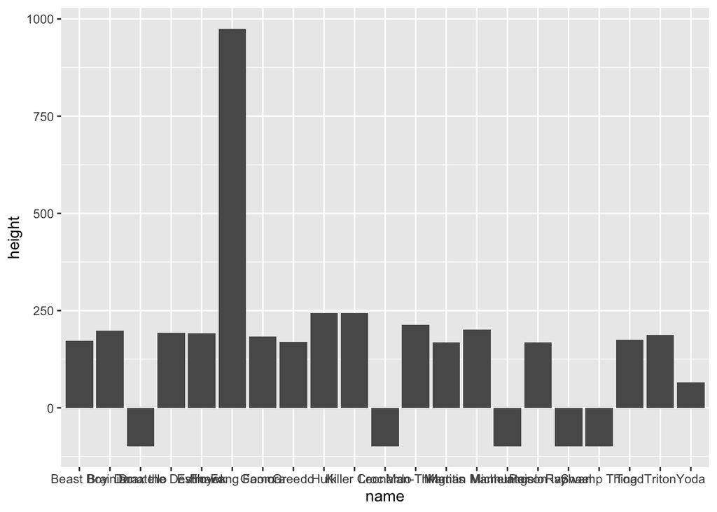

```r
superhero_info %>%
  filter(skin_color == "green") %>%
  ggplot(aes(x = name, y = height)) +
  geom_col()
```

The lines that come before the ggplot() function are piped, whereas from ggplot() onwards you have to use +. This is because we are now adding different layers and customization to the same plot.

aes() stands for aesthetics - things we can see. These set the axes for the plot, and infact you can just plot the aesthetics like this:

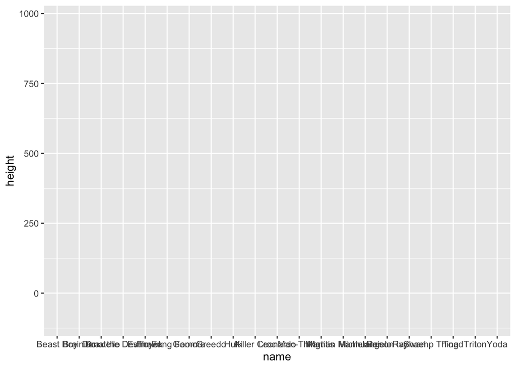

```r
superhero_info %>%
  filter(skin_color == "green") %>%
  ggplot(aes(x = name, y = height))
```

Lets clean this up a little bit- we can fix those axis labels like this:

[figure not shown]

```r
superhero_info %>%
  filter(skin_color == "green") %>%
  ggplot(aes(x = name, y = height)) +
  theme(axis.text.x = element_text(angle = 45, hjust = 1))+ # hjust sets the alignment of the text.
  geom_col()
```

[figure not shown]

```r
superhero_info %>%
  filter(skin_color == "green") %>%
  ggplot(aes(x = name, y = height)) +
  geom_col()+
  theme(axis.text.x = element_text(angle = 45, hjust = 1))+
  labs(title = "Heights of Super Heros", x = "Hero Name", y = "Height (cm)")
```

Adding another aesthetic, fill, lets us fill in color by a variable of interest.

[figure not shown]

```r
superhero_info %>%
  filter(skin_color == "green") %>%
  ggplot(aes(x = name, y = height, fill = gender)) +
  geom_col()+
  theme(axis.text.x = element_text(angle = 45, hjust = 1))+
  labs(title = "Heights of Super Heros", x = "Hero Name", y = "Height (cm)")
```

### Practice 2.

edit the code below to make a barchart of your own, choosing your own: - filter - x, y, and fill aesthetic - title and axis labels

try choosing a different x aesthetic in particular

(tip: for a barchart, usually y is numeric data. )

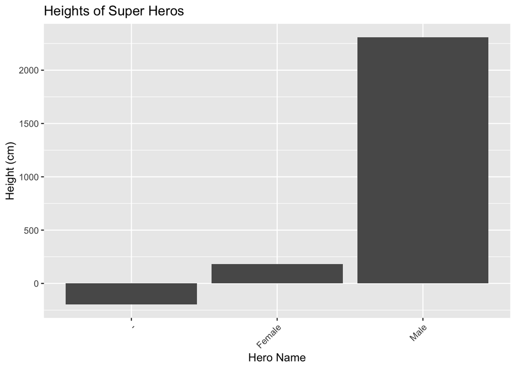

```r
superhero_info %>%
  filter(publisher == "Marvel Comics" & alignment == "neutral") %>%
  ggplot(aes(x = gender, y = height)) +
  geom_col()+
  theme(axis.text.x = element_text(angle = 45, hjust = 1))+
  labs(title = "Heights of Super Heros", x = "Hero Name", y = "Height (cm)")
```

lets test out a scatter plot, by choosing a continuous variable for both the weights and height. note that the aesthetic for coloring the points is “color”, not “fill”, and the geom() layer is “point”.

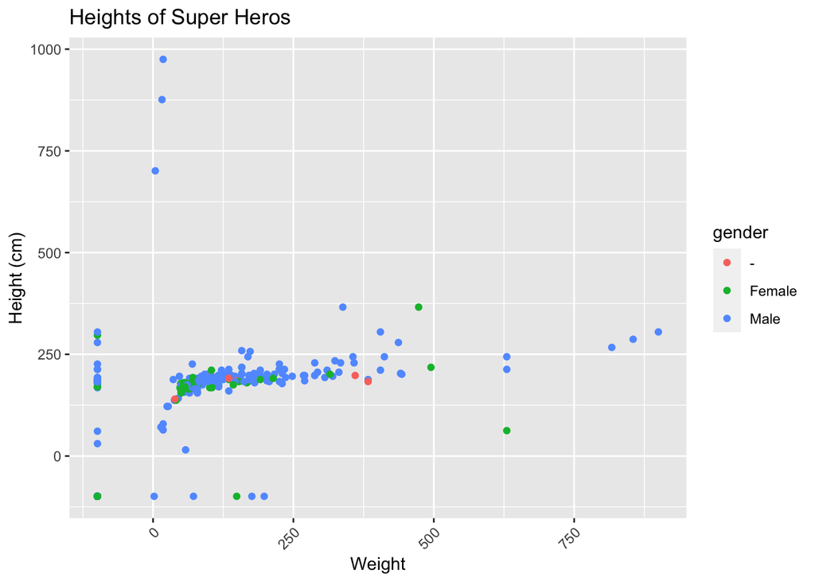

```r
superhero_info %>%
  ggplot(aes(x = weight, y = height, color = gender)) +
  geom_point()+
  theme(axis.text.x = element_text(angle = 45, hjust = 1))+
  labs(title = "Heights of Super Heros", x = "Weight", y = "Height (cm)")
```

## Applying to our microbial abundance data

Lets test out some plotting with our microbial abundance data, first by generating a relative abundance column by running the code below

```r
abundances <- read_tsv("data/FWS_OTUs.txt")
```

```
## ──────────────────────────────────────────────────────── Delimiter: "\t" chr
## (1): ...1 dbl (12): JPA_Jan, JPA_Feb, JPA_May, JPA_Jun, LOP_Jan, LOP_Feb,
## LOP_Jun, LOP...
```

```r
rel_abundances <- abundances %>%
    rename("taxonomy" = `...1`) %>%
    pivot_longer(!taxonomy, names_to = "name", values_to = "value") %>%
    separate(name, c("where", "when"), remove = F) %>%
    group_by(where, when) %>%
    mutate(relative_abundance = value/sum(value))
rel_abundances
```

```
## # A tibble: 4,644 × 6
## # Groups:   where, when [12]
##    taxonomy                           name  where when  value relative_abundance
##    <chr>                              <chr> <chr> <chr> <dbl>              <dbl>
##  1 Bacteria;Acidobacteria;Acidobacte… JPA_… JPA   Jan       0           0
##  2 Bacteria;Acidobacteria;Acidobacte… JPA_… JPA   Feb       0           0
##  3 Bacteria;Acidobacteria;Acidobacte… JPA_… JPA   May       0           0
##  4 Bacteria;Acidobacteria;Acidobacte… JPA_… JPA   Jun       0           0
##  5 Bacteria;Acidobacteria;Acidobacte… LOP_… LOP   Jan       0           0
##  6 Bacteria;Acidobacteria;Acidobacte… LOP_… LOP   Feb       0           0
##  7 Bacteria;Acidobacteria;Acidobacte… LOP_… LOP   Jun       0           0
##  8 Bacteria;Acidobacteria;Acidobacte… LOP_… LOP   Jul       0           0
##  9 Bacteria;Acidobacteria;Acidobacte… MBL_… MBL   Jan       0           0
## 10 Bacteria;Acidobacteria;Acidobacte… MBL_… MBL   Feb       3           0.000108
## # ℹ 4,634 more rows
```

Here we can make a scatter plot, plotting the relative abundance of each species by sample. adding `aplha = .5` in the geom layer makes the points 50% translucent

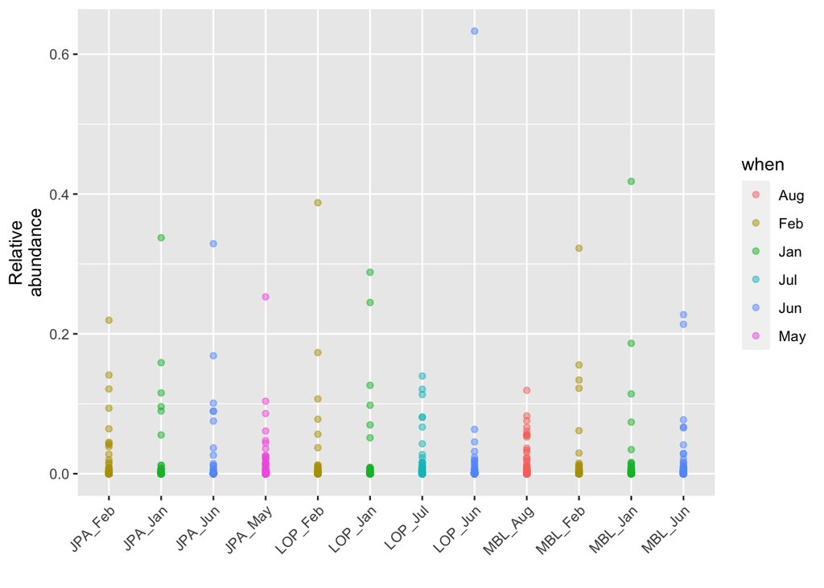

```r
rel_abundances %>%
  ggplot(aes(x = name,
             y = relative_abundance,
             col = when)) +
  geom_point(alpha=.5) +
  labs(x = "", y = "Relative\nabundance")+
  theme(axis.text.x = element_text(angle = 45, vjust = 1, hjust=1))
```

Lets test out a new plot. Here is code to make a relative abundances

```r
rel_abundances <- rel_abundances %>% mutate(when = factor(when,
                       levels = c("Jan", "Feb", "May", "Jun", "Jul", "Aug")))
```

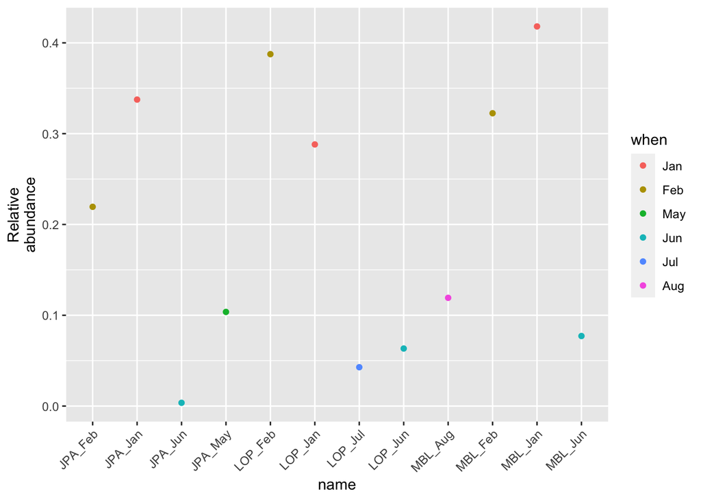

```r
rel_abundances %>%
  filter(taxonomy == "Bacteria;Proteobacteria;Betaproteobacteria;Burkholderiales;Burkholderiaceae;Ralstonia") %>%
  ggplot(aes(x = name,
             y = relative_abundance,
             col = when)) +
  geom_point() +
  labs(y = "Relative\nabundance")+
  theme(axis.text.x = element_text(angle = 45, vjust = 1, hjust=1))
```

### Practice 3.

Here is code to pivot the data again. first run this

```r
rel_abundances_wide <- abundances %>%
  rename("taxonomy" = 1) %>%
  pivot_longer(-1) %>%
  mutate(relative_abundance = value/sum(value)) %>%
  filter(taxonomy %in% c("Bacteria;Cyanobacteria;Cyanobacteria;SubsectionIV;Unassigned;Anabaena", "Bacteria;Proteobacteria;Betaproteobacteria;Burkholderiales;Burkholderiaceae;Ralstonia"))%>%
  select(!value) %>%
  pivot_wider(names_from = taxonomy,
              values_from = relative_abundance) %>%
  rename("Cyanobacteria" = 2,
         "Proteobacteria" = 3)

rel_abundances_wide
```

```
## # A tibble: 12 × 3
##    name    Cyanobacteria Proteobacteria
##    <chr>           <dbl>          <dbl>
##  1 JPA_Jan      0              0.0439
##  2 JPA_Feb      0              0.0191
##  3 JPA_May      0.000594       0.00171
##  4 JPA_Jun      0.0102         0.000412
##  5 LOP_Jan      0              0.0212
##  6 LOP_Feb      0              0.0422
##  7 LOP_Jun      0.0334         0.00335
##  8 LOP_Jul      0              0.00113
##  9 MBL_Jan      0              0.0254
## 10 MBL_Feb      0              0.0544
## 11 MBL_Jun      0.0213         0.00724
## 12 MBL_Aug      0              0.00797
```

Now, try to make a scatter plot of the relative abundances of Amy’s favorite 2 taxa, against each other.

- add the x & y aesthetics to match the 2 columns in rel_abundances_wide that represent Amy’s favorite taxa.
- debug the geom layer
- fill in the x & y labels, and add a title

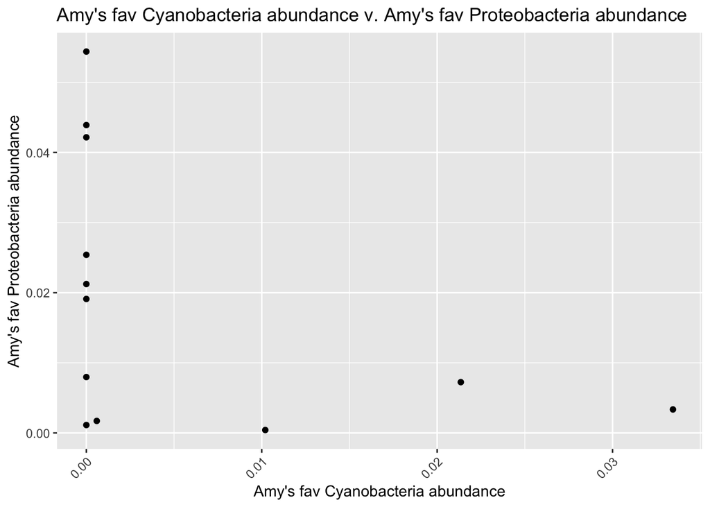

```r
rel_abundances_wide %>%
ggplot(aes(x =  Cyanobacteria,y = Proteobacteria)) +
  geom_point() +
    labs(x="Amy's fav Cyanobacteria abundance", y = "Amy's fav Proteobacteria abundance", title = "Amy's fav Cyanobacteria abundance v. Amy's fav Proteobacteria abundance")+
  theme(axis.text.x = element_text(angle = 45, vjust = 1, hjust=1))
```